# EXERCISE 10.2

Patrick Weatherford

Last modified: 11 November 2021

### Packages

```r
library(car)
library(mlogit)
library(farff)
library(Boruta)
library(dplyr)
library(rmarkdown)
library(ggplot2)
library(cowplot)
library(kableExtra)
library(ggcorrplot)
library(forcats)
library(MASS)
library(caTools)
knitr::opts_chunk$set(message=FALSE, warning=FALSE)
```

### Thoracic Surgery Logistic Regression

#### Load Data Set

```r
ts_df <- farff::readARFF("C:/Users/patwea/OneDrive - Bellevue University/BU/DSC 520 - Statistics for Data Science/Patrick.Weatherford-DSC520/dsc520-clone/data/ThoraricSurgery.arff")

glimpse(ts_df)
```

```
## Rows: 470
## Columns: 17
## $ DGN     <fct> DGN2, DGN3, DGN3, DGN3, DGN3, DGN3, DGN3, DGN2, DGN3, DGN3, DG~
## $ PRE4    <dbl> 2.88, 3.40, 2.76, 3.68, 2.44, 2.48, 4.36, 3.19, 3.16, 2.32, 2.~
## $ PRE5    <dbl> 2.16, 1.88, 2.08, 3.04, 0.96, 1.88, 3.28, 2.50, 2.64, 2.16, 2.~
## $ PRE6    <fct> PRZ1, PRZ0, PRZ1, PRZ0, PRZ2, PRZ1, PRZ1, PRZ1, PRZ2, PRZ1, PR~
## $ PRE7    <fct> F, F, F, F, F, F, F, F, F, F, F, F, F, F, F, F, F, F, F, F, F,~
## $ PRE8    <fct> F, F, F, F, T, F, F, F, F, F, T, F, F, F, F, F, T, F, F, F, F,~
## $ PRE9    <fct> F, F, F, F, F, F, F, F, F, F, F, F, F, F, F, F, F, F, F, F, F,~
## $ PRE10   <fct> T, F, T, F, T, T, T, T, T, T, T, F, T, T, T, T, F, F, T, F, F,~
## $ PRE11   <fct> T, F, F, F, T, F, F, F, T, F, F, F, T, T, F, F, F, F, F, F, F,~
## $ PRE14   <fct> OC14, OC12, OC11, OC11, OC11, OC11, OC12, OC11, OC11, OC11, OC~
## $ PRE17   <fct> F, F, F, F, F, F, T, F, F, F, F, F, F, F, F, F, F, F, F, F, F,~
## $ PRE19   <fct> F, F, F, F, F, F, F, F, F, F, F, F, F, F, F, F, F, F, F, F, F,~
## $ PRE25   <fct> F, F, F, F, F, F, F, T, F, F, F, F, F, F, F, F, F, F, F, F, F,~
## $ PRE30   <fct> T, T, T, F, T, F, T, T, T, T, F, T, T, T, T, T, T, T, T, T, T,~
## $ PRE32   <fct> F, F, F, F, F, F, F, F, F, F, F, F, F, F, F, F, F, F, F, F, F,~
## $ AGE     <dbl> 60, 51, 59, 54, 73, 51, 59, 66, 68, 54, 60, 58, 68, 80, 77, 62~
## $ Risk1Yr <fct> F, F, F, F, T, F, T, T, F, F, F, F, F, T, F, F, F, F, F, F, F,~
```

#### Feature Selection and Data Prep

##### Initial Clean

```r
## Ordering Categorical Variables Where Baseline is Least Frequent
ts_df$DGN <- forcats::fct_rev(fct_infreq(ts_df$DGN))
ts_df$PRE6 <- forcats::fct_rev(fct_infreq(ts_df$PRE6))
ts_df$PRE7 <- forcats::fct_rev(fct_infreq(ts_df$PRE7))
ts_df$PRE8 <- forcats::fct_rev(fct_infreq(ts_df$PRE8))
ts_df$PRE9 <- forcats::fct_rev(fct_infreq(ts_df$PRE9))
ts_df$PRE10 <- forcats::fct_rev(fct_infreq(ts_df$PRE10))
ts_df$PRE11 <- forcats::fct_rev(fct_infreq(ts_df$PRE11))
ts_df$PRE14 <- forcats::fct_rev(fct_infreq(ts_df$PRE14))
ts_df$PRE17 <- forcats::fct_rev(fct_infreq(ts_df$PRE17))
ts_df$PRE19 <- forcats::fct_rev(fct_infreq(ts_df$PRE19))
ts_df$PRE25 <- forcats::fct_rev(fct_infreq(ts_df$PRE25))
ts_df$PRE30 <- forcats::fct_rev(fct_infreq(ts_df$PRE30))
ts_df$PRE32 <- forcats::fct_rev(fct_infreq(ts_df$PRE32))
ts_df$Risk1Yr <- forcats::fct_relevel(ts_df$Risk1Yr, levels=c("F","T"))
ts_df$AGE_RANGE[ts_df$AGE < 30] <- 'Age <= 30'
ts_df$AGE_RANGE[ts_df$AGE >= 30 & ts_df$AGE <= 39] <- 'Age 30-39'
ts_df$AGE_RANGE[ts_df$AGE >= 40 & ts_df$AGE <= 49] <- 'Age 40-49'
ts_df$AGE_RANGE[ts_df$AGE >= 50 & ts_df$AGE <= 59] <- 'Age 50-59'
ts_df$AGE_RANGE[ts_df$AGE >= 60 & ts_df$AGE <= 69] <- 'Age 60-69'
ts_df$AGE_RANGE[ts_df$AGE >= 70 & ts_df$AGE <= 79] <- 'Age 70-79'
ts_df$AGE_RANGE[ts_df$AGE >= 80] <- 'Age >= 80'
ts_df$AGE_RANGE <- forcats::fct_rev(fct_infreq(ts_df$AGE_RANGE))

rmarkdown::paged_table(ts_df, options = list(rows.print=15))
```

| DGN | PRE4 | PRE5 | PRE6 | PRE7 | PRE8 | PRE9 | PRE10 | PRE11 | PRE14 | PRE17 | PRE19 | PRE25 | PRE30 | PRE32 | AGE | Risk1Yr | AGE_RANGE |
| --- | --- | --- | --- | --- | --- | --- | --- | --- | --- | --- | --- | --- | --- | --- | --- | --- | --- |
| DGN2 | 2.88 | 2.16 | PRZ1 | F | F | F | T | T | OC14 | F | F | F | T | F | 60 | F | Age 60-69 |
| DGN3 | 3.40 | 1.88 | PRZ0 | F | F | F | F | F | OC12 | F | F | F | T | F | 51 | F | Age 50-59 |
| DGN3 | 2.76 | 2.08 | PRZ1 | F | F | F | T | F | OC11 | F | F | F | T | F | 59 | F | Age 50-59 |
| DGN3 | 3.68 | 3.04 | PRZ0 | F | F | F | F | F | OC11 | F | F | F | F | F | 54 | F | Age 50-59 |
| DGN3 | 2.44 | 0.96 | PRZ2 | F | T | F | T | T | OC11 | F | F | F | T | F | 73 | T | Age 70-79 |
| DGN3 | 2.48 | 1.88 | PRZ1 | F | F | F | T | F | OC11 | F | F | F | F | F | 51 | F | Age 50-59 |
| DGN3 | 4.36 | 3.28 | PRZ1 | F | F | F | T | F | OC12 | T | F | F | T | F | 59 | T | Age 50-59 |
| DGN2 | 3.19 | 2.50 | PRZ1 | F | F | F | T | F | OC11 | F | F | T | T | F | 66 | T | Age 60-69 |
| DGN3 | 3.16 | 2.64 | PRZ2 | F | F | F | T | T | OC11 | F | F | F | T | F | 68 | F | Age 60-69 |
| DGN3 | 2.32 | 2.16 | PRZ1 | F | F | F | T | F | OC11 | F | F | F | T | F | 54 | F | Age 50-59 |

[output cut: 460 more lines]

##### Feature Selection

Plot Predictor Variables Against 1 Year Risk Variable

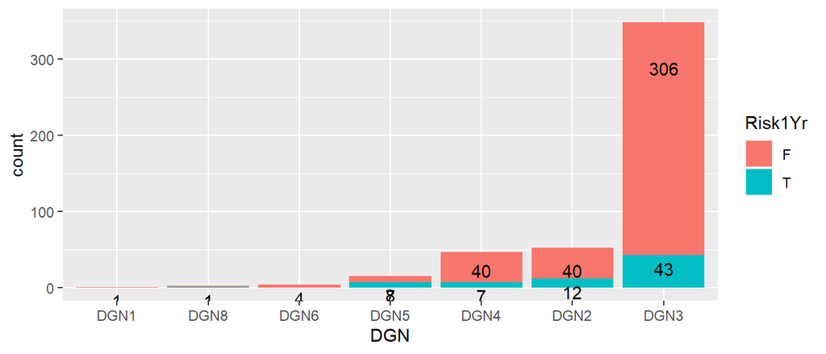

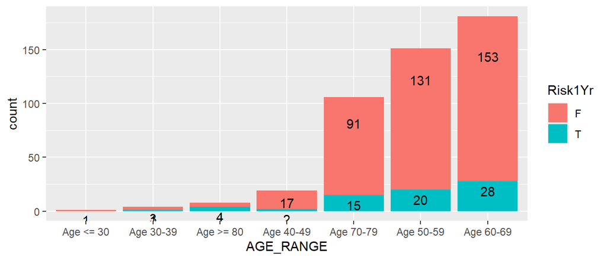

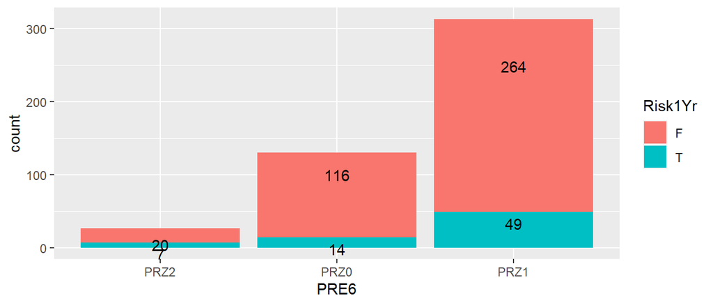

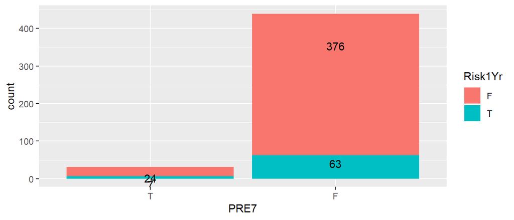

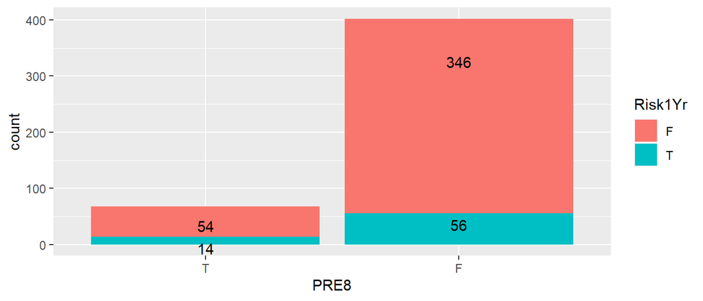

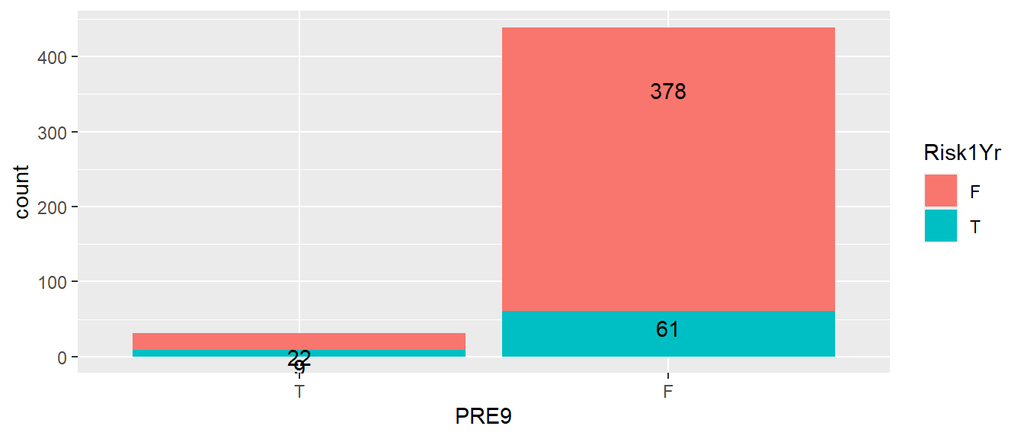

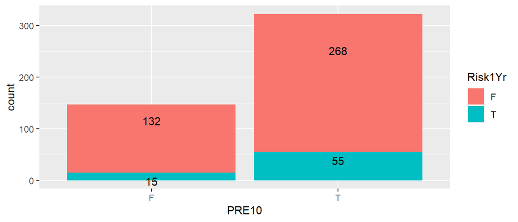

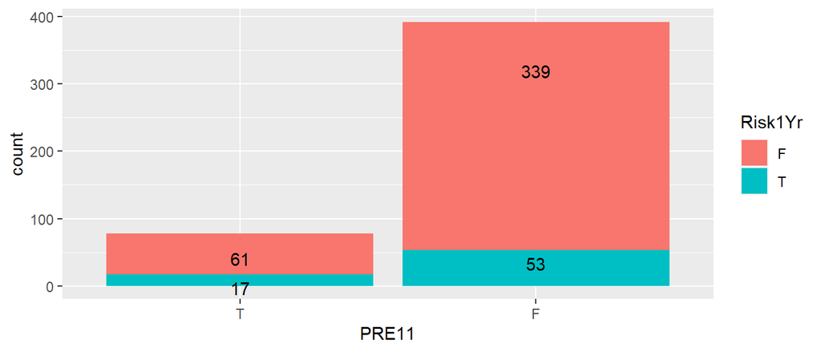

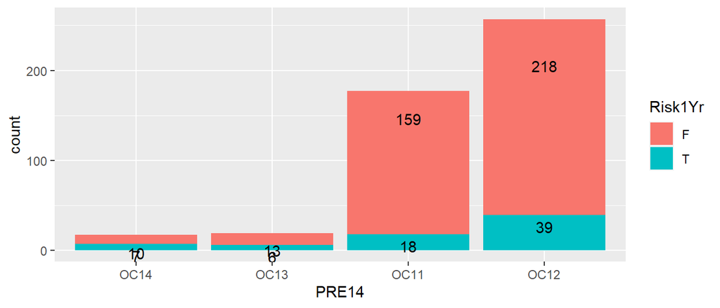

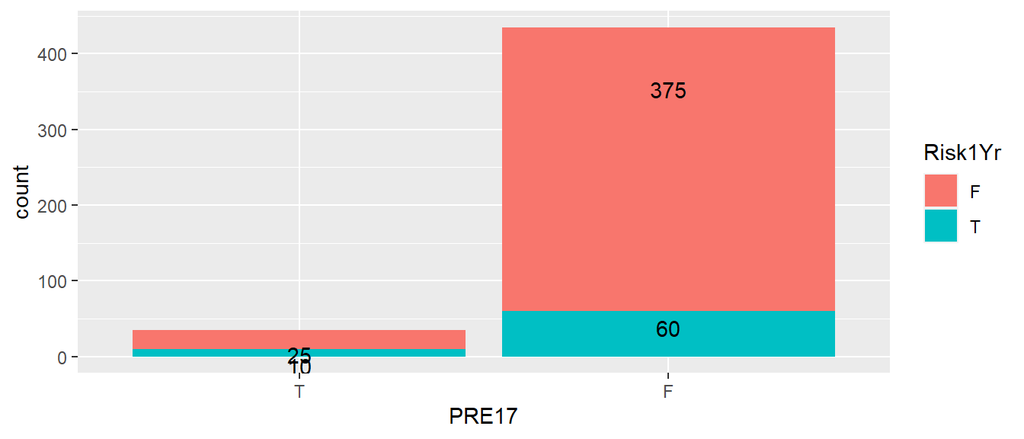

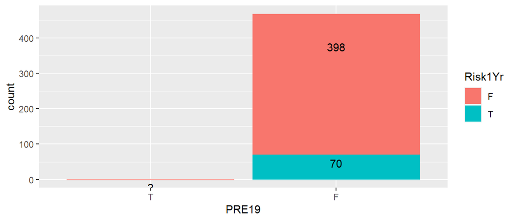

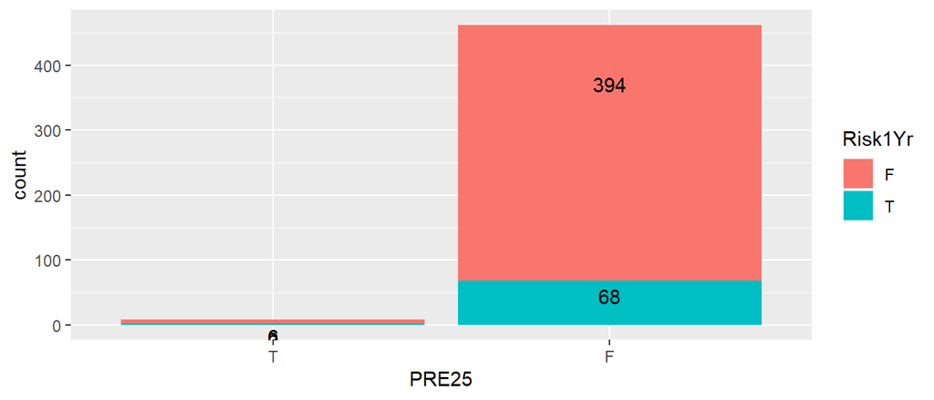

[6 more figures not shown]

```r
## Column Chart of Factor Variables
ggplot(ts_df, aes(x=DGN, fill=Risk1Yr)) + geom_bar() + geom_text(aes(label=..count..), stat="count", vjust=1.5)
ggplot(ts_df, aes(x=AGE_RANGE, fill=Risk1Yr)) + geom_bar() + geom_text(aes(label=..count..), stat="count", vjust=1.5)
ggplot(ts_df, aes(x=PRE6, fill=Risk1Yr)) + geom_bar() + geom_text(aes(label=..count..), stat="count", vjust=1.5)
ggplot(ts_df, aes(x=PRE7, fill=Risk1Yr)) + geom_bar() + geom_text(aes(label=..count..), stat="count", vjust=1.5)
ggplot(ts_df, aes(x=PRE8, fill=Risk1Yr)) + geom_bar() + geom_text(aes(label=..count..), stat="count", vjust=1.5)
ggplot(ts_df, aes(x=PRE9, fill=Risk1Yr)) + geom_bar() + geom_text(aes(label=..count..), stat="count", vjust=1.5)
ggplot(ts_df, aes(x=PRE10, fill=Risk1Yr)) + geom_bar() + geom_text(aes(label=..count..), stat="count", vjust=1.5)
ggplot(ts_df, aes(x=PRE11, fill=Risk1Yr)) + geom_bar() + geom_text(aes(label=..count..), stat="count", vjust=1.5)
ggplot(ts_df, aes(x=PRE14, fill=Risk1Yr)) + geom_bar() + geom_text(aes(label=..count..), stat="count", vjust=1.5)
ggplot(ts_df, aes(x=PRE17, fill=Risk1Yr)) + geom_bar() + geom_text(aes(label=..count..), stat="count", vjust=1.5)
ggplot(ts_df, aes(x=PRE19, fill=Risk1Yr)) + geom_bar() + geom_text(aes(label=..count..), stat="count", vjust=1.5)
ggplot(ts_df, aes(x=PRE25, fill=Risk1Yr)) + geom_bar() + geom_text(aes(label=..count..), stat="count", vjust=1.5)
ggplot(ts_df, aes(x=PRE30, fill=Risk1Yr)) + geom_bar() + geom_text(aes(label=..count..), stat="count", vjust=1.5)
ggplot(ts_df, aes(x=PRE32, fill=Risk1Yr)) + geom_bar() + geom_text(aes(label=..count..), stat="count", vjust=1.5)

## Box Plot of Continuous Variables
boxplot(ts_df$PRE4, main="PRE4")
boxplot(ts_df$PRE5, main="PRE5")
boxplot(ts_df$AGE, main="Age")

## Correlation Matrix Between Continuous Variables
cor_mat <- round(cor(ts_df[,c("PRE4","PRE5","AGE")]), 1)
ggcorrplot(cor_mat, lab = TRUE, hc.order=TRUE, type="lower", title="Variable Correlation")
```

```r
## Create dummy variable where DGN=DGN3
ts_df$DGN3 <- ifelse(ts_df$DGN=="DGN3",1,0)

## Create dummy variable where Age >= 50
ts_df$OVER_50 <- ifelse(ts_df$AGE >= 50,1,0)

## Create data frame variable with category variable that need to become dummy variables
ts_df_cat <- dplyr::select(ts_df, PRE6, PRE7, PRE8, PRE9, PRE10, PRE11, PRE14, PRE17, PRE19, PRE25, PRE30, PRE32)


## Use sapply() to easily convert all variables in category data frame into dummy variables
ts_df_dummy <- data.frame(sapply(ts_df_cat, function(x) data.frame(model.matrix(~x-1, data=ts_df_cat))[,-1]))

## Select Columns and Rename to meaningful name
ts_df_dummy <- ts_df_dummy %>%
  dplyr::select(
    PRE6_PRZ0="PRE6.xPRZ0"
    , PRE6_PRZ1="PRE6.xPRZ1"
    , PRE7
    , PRE8
    , PRE9
    , PRE10
    , PRE11
    , PRE14_OC13="PRE14.xOC13"
    , PRE14_OC11="PRE14.xOC11"
    , PRE14_OC12="PRE14.xOC12"
    , PRE17
    , PRE19
    , PRE25
    , PRE30
    , PRE32
  )

## Remove redundant columns from main data frame
ts_df <- ts_df[,c("Risk1Yr","PRE4","PRE5","DGN3","OVER_50")]

## Combain main data frame with dummy data frame
ts_df <- cbind(ts_df, ts_df_dummy)


rmarkdown::paged_table(ts_df, options=list(rows.print=15))
```

|  | Risk1Yr | PRE4 | PRE5 | DGN3 | OVER_50 | PRE6_PRZ0 | PRE6_PRZ1 | PRE7 | PRE8 | PRE9 | PRE10 | PRE11 | PRE14_OC13 | PRE14_OC11 | PRE14_OC12 | PRE17 | PRE19 | PRE25 | PRE30 | PRE32 |
| --- | --- | --- | --- | --- | --- | --- | --- | --- | --- | --- | --- | --- | --- | --- | --- | --- | --- | --- | --- | --- |
| 1 | F | 2.88 | 2.16 | 0 | 1 | 0 | 1 | 1 | 1 | 1 | 1 | 0 | 0 | 0 | 0 | 1 | 1 | 1 | 1 | 1 |
| 2 | F | 3.40 | 1.88 | 1 | 1 | 1 | 0 | 1 | 1 | 1 | 0 | 1 | 0 | 0 | 1 | 1 | 1 | 1 | 1 | 1 |
| 3 | F | 2.76 | 2.08 | 1 | 1 | 0 | 1 | 1 | 1 | 1 | 1 | 1 | 0 | 1 | 0 | 1 | 1 | 1 | 1 | 1 |
| 4 | F | 3.68 | 3.04 | 1 | 1 | 1 | 0 | 1 | 1 | 1 | 0 | 1 | 0 | 1 | 0 | 1 | 1 | 1 | 0 | 1 |
| 5 | T | 2.44 | 0.96 | 1 | 1 | 0 | 0 | 1 | 0 | 1 | 1 | 0 | 0 | 1 | 0 | 1 | 1 | 1 | 1 | 1 |
| 6 | F | 2.48 | 1.88 | 1 | 1 | 0 | 1 | 1 | 1 | 1 | 1 | 1 | 0 | 1 | 0 | 1 | 1 | 1 | 0 | 1 |
| 7 | T | 4.36 | 3.28 | 1 | 1 | 0 | 1 | 1 | 1 | 1 | 1 | 1 | 0 | 0 | 1 | 0 | 1 | 1 | 1 | 1 |
| 8 | T | 3.19 | 2.50 | 0 | 1 | 0 | 1 | 1 | 1 | 1 | 1 | 1 | 0 | 1 | 0 | 1 | 1 | 0 | 1 | 1 |
| 9 | F | 3.16 | 2.64 | 1 | 1 | 0 | 0 | 1 | 1 | 1 | 1 | 0 | 0 | 1 | 0 | 1 | 1 | 1 | 1 | 1 |
| 10 | F | 2.32 | 2.16 | 1 | 1 | 0 | 1 | 1 | 1 | 1 | 1 | 1 | 0 | 1 | 0 | 1 | 1 | 1 | 1 | 1 |

[output cut: 460 more lines]

#### Logistic Regression

##### Multiple R2 Function

```r
log_r2 <- function(log_model) {
  dev <- log_model$deviance
  null_dev <- log_model$null.deviance
  model_n <- length(log_model$fitted.values)
  AIC <- log_model$aic
  R.L <- (null_dev - dev)/null_dev
  R.CS <- 1-exp(-(null_dev - dev)/model_n)
  R.N <- R.CS / ( 1 - ( exp (-(null_dev / model_n))))
  data.frame(
    "Deviance"=dev
    , "NULL Devience"=null_dev
    , "AIC"=log_model$aic
    , "R.squared L"=R.L
    , "R.squared CS"=R.CS
    , "R.squared N"=R.N
    , "Model N"=model_n
  )
}
```

##### Model

```r
ts_glm_all <- glm(Risk1Yr ~ ., data=ts_df, family="binomial")
```

##### Summary of Model

> Results from summary:
> - DGN where equal to DGN3 has a beta of -0.77 and is significant at p < 0.01.
> - PRE9 where equal to ‘F’ has a beta of -1.31 and is significant at p < 0.01.
> - PRE14 where equal to OC11 has a beta of -1.53 and is significant at p < 0.05.
> - PRE14 where equal to OC12 has a beta of -1.14 and is significant at p < 0.05.
> - PRE17 where equal to ‘F’ has a beta of -0.91 and is significant at p < 0.05.
> - NULL deviance from baseline model = 395.61
> - Deviance from model = 352.87
> - Chi-Square Statistic = 42.74

```r
summary(ts_glm_all)
```

```
##
## Call:
## glm(formula = Risk1Yr ~ ., family = "binomial", data = ts_df)
##
## Deviance Residuals:
##     Min       1Q   Median       3Q      Max
## -1.5438  -0.5734  -0.4293  -0.3190   2.4291
##
## Coefficients:
##               Estimate Std. Error z value Pr(>|z|)
## (Intercept)  -23.55317 1418.56402  -0.017  0.98675
## PRE4          -0.18480    0.17588  -1.051  0.29338
## PRE5          -0.02614    0.01721  -1.518  0.12891
## DGN3          -0.76717    0.29616  -2.590  0.00959 **
## OVER_50       -0.17092    0.71700  -0.238  0.81159
## PRE6_PRZ0      0.51119    0.76544   0.668  0.50424
## PRE6_PRZ1     -0.04017    0.55766  -0.072  0.94257
## PRE7          -0.78069    0.53923  -1.448  0.14767
## PRE8          -0.16294    0.37820  -0.431  0.66659
## PRE9          -1.31232    0.48544  -2.703  0.00686 **
## PRE10          0.58408    0.47511   1.229  0.21894
## PRE11         -0.56733    0.38606  -1.470  0.14169
## PRE14_OC13    -0.37446    0.76900  -0.487  0.62630
## PRE14_OC11    -1.52667    0.59819  -2.552  0.01071 *
## PRE14_OC12    -1.13758    0.57735  -1.970  0.04880 *
## PRE17         -0.91214    0.43501  -2.097  0.03601 *
## PRE19         13.59108 1002.72914   0.014  0.98919
## PRE25         -0.14983    0.92514  -0.162  0.87135
## PRE30          0.83500    0.45394   1.839  0.06585 .
## PRE32         13.01919 1003.42171   0.013  0.98965
## ---
## Signif. codes:  0 '***' 0.001 '**' 0.01 '*' 0.05 '.' 0.1 ' ' 1
##
## (Dispersion parameter for binomial family taken to be 1)
##
##     Null deviance: 395.61  on 469  degrees of freedom
## Residual deviance: 352.87  on 450  degrees of freedom
## AIC: 392.87
##
## Number of Fisher Scoring iterations: 14
```

##### Accuracy of Model on Sample

> Threshold: 0.5
> - Overall Accuracy: 84%
> - Mis-classification: 16%
> - Sensitivity (True Positive Rate): 0%
> - Specificity (True Negative Rate): 99%

```r
ts_df$predicted <- factor(ifelse(predict(ts_glm_all, ts_df)> 0.5, "T","F"), levels=c("T","F"))

table(actual=ts_df$Risk1Yr, predicted=ts_df$predicted)
```

```
##       predicted
## actual   T   F
##      F   2 398
##      T   0  70
```

### Binary Classifier Data

#### Load Data Set

```r
bc_df <- read.csv("C:/Users/patwea/OneDrive - Bellevue University/BU/DSC 520 - Statistics for Data Science/Patrick.Weatherford-DSC520/dsc520-clone/data/binary-classifier-data.csv", header = T)

glimpse(bc_df)
```

```
## Rows: 1,498
## Columns: 3
## $ label <int> 0, 0, 0, 0, 0, 0, 0, 0, 0, 0, 0, 0, 0, 0, 0, 0, 0, 0, 0, 0, 0, 0~
## $ x     <dbl> 70.88469, 74.97176, 73.78333, 66.40747, 69.07399, 72.23616, 70.9~
## $ y     <dbl> 83.17702, 87.92922, 92.20325, 81.10617, 84.53739, 86.38403, 89.7~
```

> Results from summary:
> - ‘x’ has a beta of -0.0006 and is not significant with p > 0.05.
> - ‘y’ has a beta of -0.002 and is significant at p < 0.001
> - NULL deviance from baseline model = 374.28
> - Deviance from model = 368.39
> - Chi-Square Statistic = 5.89

> Model Accuracy (Threshold 0.5)
> - Overall accuracy: 58.3%
> - Misclassification: 41.7%
> - Sensitivity: 60.9%
> - Specificity: 55.9%

```r
bc_glm_all <- glm(label ~., data=bc_df)
summary(bc_glm_all)
```

```
##
## Call:
## glm(formula = label ~ ., data = bc_df)
##
## Deviance Residuals:
##     Min       1Q   Median       3Q      Max
## -0.6108  -0.4956  -0.3664   0.4925   0.6253
##
## Coefficients:
##               Estimate Std. Error t value Pr(>|t|)
## (Intercept)  0.6049208  0.0287423  21.046  < 2e-16 ***
## x           -0.0006309  0.0004481  -1.408    0.159
## y           -0.0019662  0.0004578  -4.295 1.86e-05 ***
## ---
## Signif. codes:  0 '***' 0.001 '**' 0.01 '*' 0.05 '.' 0.1 ' ' 1
##
## (Dispersion parameter for gaussian family taken to be 0.2464139)
##
##     Null deviance: 374.28  on 1497  degrees of freedom
## Residual deviance: 368.39  on 1495  degrees of freedom
## AIC: 2157.8
##
## Number of Fisher Scoring iterations: 2
```

```r
bc_df$predicted <- ifelse(predict(bc_glm_all, bc_df)> 0.5, 1,0)

conf_matrix <- as.matrix(table(actual=bc_df$label, predicted=bc_df$predicted))

conf_matrix
```

```
##       predicted
## actual   0   1
##      0 429 338
##      1 286 445
```

```r
model_accuracy_0.5 <- round(100 * sum(conf_matrix[c(1,4)]) / sum(conf_matrix), 1)
mis_class_0.5 <- 100-model_accuracy_0.5
sensitivity_0.5 <- round(100 * sum(conf_matrix[c(4)]) / sum(conf_matrix[c(2,4)]), 1)
specificity_0.5 <- round(100 * sum(conf_matrix[c(1)]) / sum(conf_matrix[c(1,3)]), 1)

model_accuracy_0.5
```

```
## [1] 58.3
```

```r
mis_class_0.5
```

```
## [1] 41.7
```

```r
sensitivity_0.5
```

```
## [1] 60.9
```

```r
specificity_0.5
```

```
## [1] 55.9
```